# Predicting Success in March Madness from Regular Season Metrics

##### by John Taormina, Jared Welsh, Will Snyder

## Goal: Compare the Influence of Regular Season Performance and Team Experience on Team Success in March Madness.

### Purpose:

Why study college basketball statistics? How much insight could you really get from a complex set of variables all influenced by the interactions of the human body, the general state of the sport over time, player mentality, team politics and morale, and team experience? This a very valid question. One could say that you shouldn't even attempt to fully comprehend the seemingly quantum-mechanics-level complexity of these variables as they play out **between players**. Instead, you should attempt to distinguish between the influence of bigger picture metrics **at the team level**.

A logical starting point for determining the traits that make or break a team would be relating these traits to team success in March Madness. March Madness is a best-of-one tournament that moves at breakneck speed. The mental weight and intensity of March Madness implies the importance of one particular dynamic: **objective sense of a team's skill vs. its players' experience.** A skilled team that did well in the regular season has a reasonable chance of success in the playoffs. This is undoubtadly true, but the experience of that team implies cohesion and leadership: crucial traits for weathering the playoff storm.

This tutorial does not aim to create a money-printing bracket generator. We will test simple models with simple configurations. The greatest strength of this tutorial is the **extensively documented scraping process**. We account for minor data inconsistencies, issues you might find when requesting large amounts of data via script, campatibility issues between systems, parsing HTLM DOM trees directly, and more.

### Structural Overview:

This tutorial consists of three parts: scraping, cleaning and organization, and analysis. It will walk you through the retrieval of 30 plus years of college basketball data from HTML tables to Pandas dataframes. You will organize this data in a logical manner and perform simple linear regression analysis to find key relationships. The data will be pulled from www.sports-reference.com. All compound metrics included in this database are **consistently defined**.

Of course, this tutorial does not present functions in exact execution order. This tutorial presents each function in a logical ordering based on its **role in the data science life cycle**. For example, the scraping functions are defined in the scraping section. These scraping functions may be called from functions the organization section, or from other functions listed in the scraping section. Don't stress about the exact ordering of code; it is necessary for compliance with Python code structure and logical ordering in the data science life cycle.

If you wish to understand the inner programmatic structure of each function, they are commented extensively for that purpose. Important warnings related to common pitfalls are noted when relevant for each function.

Links to explanations of metrics by the analysts that created them are provided and further reading is mentioned at the conclusion.

### Table of Contents:

1. Data Overview
2. Scraping
3. Organization
4. Regression
5. Evaluation
6. Conclusions and Further Reading

### Libraries you will need (all available through pip/Anaconda):

1. Pandas
2. Beautfiul Soup and requests
3. math and Numpy
4. os and sys
5. Matplotlib and plotly (see comments in section below)
6. google
7. statsmodels

```python
import sys
!{sys.executable} -m pip install lxml


from bs4 import BeautifulSoup

import requests
import pandas as pd
import re
from math import floor, ceil
import numpy as np
import seaborn as sns

import statsmodels.formula.api as smf

from collections import Counter

import matplotlib.pyplot as plt
from matplotlib.lines import Line2D

from googlesearch import search
import pathlib
import os.path
from os import path


pd.set_option("display.max_rows", None)
pd.set_option("display.max_columns", None)


#Plotly sometimes does not import properly on MACs.  We were not able to find a solution for this.
#If you know it will work on your machine, uncomment these lines so you can view scatterplots in the
#second half of the evalution step.

#import plotly
#import plotly.express as px
```

# Data Overview

Our data consists of:

1. SRS - Simple Rating System: #average point differential of all regular season games played/#average differential of all opponents.  
   a. A thorough walkthrough of the logic behind this ranking system can be found [here](https://www.pro-football-reference.com/blog/index4837.html?p=37)
2. SOS - Strength of Schedule: #average point differential of opponents.
3. OSRS, DSRS: Offensive and Defensive Variations on SRS
4. Player Experience: sum over top ten players on team{ player's rank on team *weight* SRS/100 }
5. Raw Player Experience: sum over top ten players on team{ player's rank on team * weight }  
   a. The weight is defined by this mapping: Freshman: 1.0, Sophomore: 1.1, Junior: 1.2, Senior: 1.3.  
   b. Teammates are ranked relative to eachother by points + rebounds + assists
6. Team Wins: Simply the number of wins earned by a team in the playoffs. Its exact interpreation is detailed before the modeling process.

Regular season team data (1-3) are all stored in a single table per year.

[figure not shown]

Both Player Experience features are drawn from roster data stored in a single table per team per year (hence the lengthy scraping time...). We offer CSV files that already contain this data in the repo root in case you do not wish wait 5-10 minutes.

[figure not shown]

Team Wins is drawn from brackets stored as DOM trees. The tournament scraping section goes into much greater detail.

[figure not shown]

These metrics are defined consistently throughout the years on www.sports-reference.com. We could not find many examples of missing data either. Sports-reference is a great website for sports statistics and they have much more to offer than college basketball.

Back to Table of Contents

# Scraping Functions

This tutorial requires college basketball data from 1988 to 2019. An excellent source for this can be found at www.sports-reference.com. We will iterate through their database year by year, team by team and convert the html tables into Pandas Dataframes.

1. Part A - Rosters
2. Part B - Tournaments
3. Part C - Regular Seasons

Back to Table of Contents

**NOTE:** Team names are abbreviated in some tables. The 'abbreviation_map' dictionary and 'fix_name' function below solve that issue.

```python
abbreviation_map = {
    'UNC': 'North Carolina', 'NC State': 'North Carolina State', 'USC': 'Southern California',
    'ETSU': 'East Tennessee State', 'VCU': 'Virginia Commonwealth', 'LSU': 'Louisiana State', 'UConn': 'Connecticut',
    'BYU': 'Brigham Young', 'Pitt': 'Pittsburgh', 'UNLV': 'Nevada-Las Vegas', 'UMBC': 'Boston College',
    'St. Joseph\'s': 'Saint Joseph\'s', 'California': 'University of California', 'UCSB': 'UC-Santa Barbara',
    'UTEP': 'Texas-El Paso', 'UTSA': 'Texas-San Antonio', 'LIU-Brooklyn': 'Long Island University',
    'St. Peter\'s': 'Saint Peter\'s', 'Saint Mary\'s': 'Saint Mary\'s (CA)',
    'UNC Asheville': 'North Carolina-Asheville', 'Penn': 'Pennsylvania', 'TCU': 'Texas Christian',
    'UNC Greensboro': 'North Carolina-Greensboro', 'UNC Wilmington': 'North Carolina-Wilmington',
    'Ole Miss': 'Mississippi', 'SMU': 'Southern Methodist', 'UMass': 'Massachusetts',
    'Southern Miss': 'Southern Mississippi', 'Detroit': 'Detroit Mercy'
}

def fix_name(tag):
    return abbreviation_map[tag.text] if tag.text in abbreviation_map.keys() else tag.text
```

### Part A: Scraping Roster Data per Team per Year

This function saves roster files for each team for each year in CSV files. If you don't already have the CSV files, this will take a while. We suggest you download them directly.

**IMPORTANT NOTES:**

```python
# This function downloads the roster csv files according to each year and saves them
# in a local directory for easier access and manipulation
# We believed this was necessary because requesting the rosters each time
# we wanted to rerun the program took too long, so saving them was much easier.

# This function works by "guessing" each teams roster url with /cbb/schools/TEAMNAME/YEAR
# If this does not result in a successful lookup of a page, then it makes a google search
# and uses regex to find the correct link (@ second if-statement).  This may not occur at all,
# it seems to vary by user.

def generate_all_roster_csv(year):
    tourney_wins = get_tourney_wins(year)
    playoff_teams = tourney_wins.keys()
    count = 0
    for team in playoff_teams:
        count = count + 1
        if(not not(path.exists('rosters' + '/' + str(year) + '/' + team + '.csv'))):
            pass
        else:
            team_rep = team.replace(' ','-')
            team_rep = team_rep.lower()
            find_url = 'https://www.sports-reference.com/cbb/schools/'+team_rep+'/2019.html'
            req = requests.get(find_url)

            #Using the google library to get around a scraper block.
            if(req.status_code == 404):
                search_term = team + ' ' + str(year) + ' site:https://www.sports-reference.com/cbb/'
                team_url = ''
                for url in search(search_term, num=5, pause=4.0, user_agent='your mom'):
                    team_url = url
                    if(re.match(r"^https:\/\/www\.sports-reference\.com\/cbb\/[\w+(?:\-\w+)+\/]*"+str(year)+"\.html$", team_url)):
                        break
                req = requests.get(team_url)
                soup = BeautifulSoup(re.sub("<!--|-->", "", req.text), 'html.parser')
                table = soup.findAll('table', id="roster")[0]
                roster_df = pd.read_html(str(table))
                pathlib.Path('rosters' + '\\' + str(year)).mkdir(parents=True, exist_ok=True)
                save_path = 'rosters' + '\\' + str(year) + '\\' + team + '.csv'
                roster_df[0].to_csv(save_path)
            else:
                soup = BeautifulSoup(re.sub("<!--|-->", "", req.text), 'html.parser')
                table = soup.findAll('table', id="roster")[0]
                roster_df = pd.read_html(str(table))
                pathlib.Path('rosters' + '\\' + str(year)).mkdir(parents=True, exist_ok=True)
                save_path = 'rosters' + '\\' + str(year) + '\\' + team + '.csv'
                roster_df[0].to_csv(save_path)
```

### Part B: Scraping Tournament Data per Year per Team

Next we must iterate through each year and team to get records of each tournament (March Madness). We then return a dictionary linking teams to their tournament wins for each year (a Pandas column). This data is not in a table on sports-reference. It is stored as a tree (tournament bracket) of div elements. This is relatively easy to traverse. We determine the # of wins a team got for that year by simply counting the # of times a team's name appears in the tree. The comments below go into greater detail on the HTML DOM parsing process.

```python
# The function first creates an empty list that will hold the names that appear in the bracket.
# Next, we get the url and remove comments. When then find the div item that houses the bracket. From there
# we look at the children of the div, skipping every other element because they aren't the brackets.
# There are two different types of brackets, conference brackets and the final four. Because the final four
# bracket has a different id, we need to account for that in the first line. From there we continue into the
# html until we find the element that houses the team names. From there we get all of the team names and replace
# them with their ratings counterpart, to ensure name standardization. finally we return the counter representation
# of our list, giving us a dictionary with team names and their tourney wins.

def get_tourney_wins(year):
    playoff_teams = []

    url = 'https://www.sports-reference.com/cbb/postseason/'+str(year)+'-ncaa.html'
    req = requests.get(url)
    soup = BeautifulSoup(re.sub("<!--|-->", "", req.text), 'html.parser')

    b = soup.find('div', {'id' : 'brackets'})

    for conf in list(b.children)[1::2]:
        cls = 'team4' if 'national' in conf.get('id') else 'team16'
        bracket = conf.find('div', {'class': cls})
        rnds = bracket.findAll('div', {'class': 'round'})
        for rnd in rnds:
            divlist = filter(lambda a: 'schools' in a['href'], rnd.findAll('a'))
            playoff_teams += [fix_name(a) for a in divlist]


    return dict(Counter(playoff_teams))
```

### Part C: Scraping Performance Data per Year per Team

This function creates scrapes each team's SRS, SOS, DSRS, and OSRS for each year into a dataframe. It also calls get_tourney_wins, and merges the returned dataframe with the aforementioed performance dataframe. There are numerous quirks to this method, please see the comments for more detail.

```python
# This function accepts a year, which is used in creating the url for the data we are trying to access.
# In this function we first call the get_tourney_wins function.
# This function is called first because we only care about teams that made it to the tournament.
# The ratings page has all teams that competed that year. In order to save time we remove all teams
# that did not make the playoffs.

def generate_df(year):
    tourney_wins = get_tourney_wins(year)
    playoff_teams = tourney_wins.keys()

    # Next, we use requests to get the html page containing the ratings for each year. We remove the comments
    # from the document to make parsing easier. We then get the table tag, which has all the schools ratings.
    # We create a dataframe from the table. Every 20 entries on the website, a new table is used/
    # Due to the way that the data is laid out on the website, multiple dataframes are actually created
    # when calling read_html. In order to combine these dataframes, we use concat. We also need to droplevel
    # to fix the column names. If we do not use this, the column names are set as the first row of data.

    req = requests.get('https://www.sports-reference.com/cbb/seasons/'+str(year)+'-ratings.html')
    soup = BeautifulSoup(re.sub("<!--|-->", "", req.text), 'html.parser')
    table = soup.findAll('table')
    s_df = pd.read_html(str(table))

    # Now that the dataframe is beginning to take shape, we remove all columns that aren't needed. From there,
    # we remove all rows that do not contain data. Because of the way the table is laid out on the website,
    # the column names appear multiple times as data. We remove this and reset the index.
    # From there we add new columns used for managing the year, flags to drop non-playoff teams and additionally
    # prep column filled out later.

    temp_df = (pd.concat(s_df))
    temp_df.columns = temp_df.columns.droplevel()
    temp_df.reset_index(drop=True, inplace=True)

    standings_df = temp_df[['School', 'SRS', 'SOS', 'OSRS', 'DSRS']].copy()
    standings_df = standings_df[~standings_df.SRS.str.contains("SRS")]
    standings_df.dropna(inplace=True)

    standings_df['EXP'] = 0.0
    standings_df['year'] = year
    standings_df['playoff'] = False
    standings_df['t_wins'] = 0

    # From here we change the column type to a numerical value for later use and update the tournament wins for
    # each team. We then drop all non-tournament teams using the column we created and then remove that column.

    standings_df.SRS = standings_df.SRS.astype(float)
    standings_df.OSRS = standings_df.OSRS.astype(float)
    standings_df.DSRS = standings_df.DSRS.astype(float)
    standings_df.SOS = standings_df.SOS.astype(float)



    for indx, row in standings_df.iterrows():
        if row['School'] in playoff_teams:
            wins = tourney_wins[row['School']]
            standings_df.loc[indx, 'playoff'] = True
            standings_df.loc[indx, 't_wins'] =  wins - 1 if wins < 5 else wins - 2 #Winning team listed one more time in tree.


    standings_df = standings_df[standings_df.playoff].reset_index(drop=True)
    del standings_df['playoff']
    return standings_df
```

# Organization and Preprocessing

Before we begin fitting our linear regression model to our data, we need to get all of our data in one place and refine our metrics a little.

1. Part A - Experience CSVs -> Dataframes
2. Part B - Combining Performance and Experience Dataframes
3. Part C - Preprocessing

Back to Table of Contents

### Part A: Migrating Team Roster Data from CSV to Pandas

Now that we've got our roster data in CSV files, we need to store it in a Pandas dataframe. Once we've done this, for each team for each year, we can calculate total player experience.

If the best players on a team are all seniors, the player experience metric is maximized, since you have skilled players with leadership capabilities and knowledge. If a team's best players are mostly freshmen who have not faced the pressure of playoffs, the experience metric will reflect that.

**IMPORTANT NOTES:**

1. When calling calculate_player_experience, make sure you use the appropriate path delimiters for your operating system. '/' (MAC-OS) is the delimiter used by default; if you are using Windows, replace them with '\\' in the cell below.
2. This tutorial assumes you have already downloaded the CSVs from the main repository. We STRONGLY recommend this for times sake because searching through all the roster data, formatting it, and saving it can take a while. If you wish to scrape them yourself, uncomment the first 3 lines of the cell below.

```python
# roster_team_links = {}
# for year in range(1988,2020):
#     generate_all_roster_csv(year)

# This fuction calculates a player experience variable that
# takes into account the skill of a player, and how old they are (FR, SO, JR, SR)

def calculate_player_experience(year, team):
    df_path = 'rosters' + '/' + str(year) + '/' + team + '.csv'
    df = pd.read_csv(df_path)
    # Weights based on each starter, then bench as a whole player
    start_weight = 10
    class_weights = {'FR': 1.0, 'SO': 1.1, 'JR': 1.2, 'SR': 1.3}
    player_exp = 0
    df = df.fillna('X')

    for index, row in df.iterrows():

        if(row['Class'] != 'X'):

            player_exp = player_exp + class_weights[row['Class']]*start_weight
            player_exp = round(player_exp, 2)

            start_weight = start_weight - 1

            if start_weight == 0: break

    return(player_exp)
```

Now that we have a function to calculate a team's total experience for a particular year, we build a dataframe holding that data for every team per year.

```python
# This function works very similarly to generate_df... except it creates columns for
# tournament experience and roster experience instead

def generate_exp_df(year):
    tourney_wins = get_tourney_wins(year)
    playoff_teams = tourney_wins.keys()
    School = []
    year_arr = []
    player_exp = []
    player_exp_raw = []
    tourn_exp = []
    for team in playoff_teams:
        School.append(team)
        year_arr.append(year)
        player_exp.append(calculate_player_experience(year, team))
        player_exp_raw.append(calculate_player_experience(year, team))
    experience_df = pd.DataFrame.from_dict({'School':School, 'year': year_arr, 'player_exp': player_exp, 'player_exp_raw' : player_exp_raw})
    return(experience_df)
```

### Part B: Putting the Team Experience and Team Performance Dataframes Together

This is the step that actually calls our previously defined functions. This step generates two lists of dataframes for the years 1988-2019. One list will contain team performance dataframes for each year (recall that these dataframes contain a team's regular season performance metrics and #wins they achieved in March Madness) and other will contain team experience dataframes for each year.

Once we have these dataframes merged, we can begin our analysis.

```python
# This code calls the functions used to create the performance and experience dataframes and then adds
# them all to a list for each year. After that it combines all the dataframes together and resets the
# index. It saves the year range to be used later to create the legend and the new means dataframe.

df_list = []
print("\nGenerating Performance Dataframes...\n")

for i in range(1988, 2019):
    a = ', ' if i != 2019 else '.'
    print('{}{}'.format(i, a), end='')
    df_list.append((generate_df(i)))

df = pd.concat(df_list)
df.reset_index(drop=True, inplace=True)


df = df[['School', 'year', 't_wins', 'SOS', 'SRS', 'OSRS', 'DSRS']]
```

```
Generating Performance Dataframes...

1988, 1989, 1990, 1991, 1992, 1993, 1994, 1995, 1996, 1997, 1998, 1999, 2000, 2001, 2002, 2003, 2004, 2005, 2006, 2007, 2008, 2009, 2010, 2011, 2012, 2013, 2014, 2015, 2016, 2017, 2018,
```

```python
exp_list_df = []
print("\n\nGenerating Experience Dataframes...\n")


for i in range(1988, 2019):
    a = ', ' if i != 2019 else '.'
    print('{}{}'.format(i, a), end='')
    exp_list_df.append((generate_exp_df(i)))

exp_df = pd.concat(exp_list_df)
exp_df.reset_index(drop=True, inplace=True)


print("\n\nJoining Performance and Experience Dataframes...")

joined_df = pd.merge(df, exp_df, how='left', on=['School','year'])

print("\nDone.")
```

```
Generating Experience Dataframes...

1988, 1989, 1990, 1991, 1992, 1993, 1994, 1995, 1996, 1997, 1998, 1999, 2000, 2001, 2002, 2003, 2004, 2005, 2006, 2007, 2008, 2009, 2010, 2011, 2012, 2013, 2014, 2015, 2016, 2017, 2018,

Joining Performance and Experience Dataframes...

Done.
```

### Part C: Preprocessing

Now that we have everything in one dataframe, we need to refine our player experience and team performance metrics to work well with linear regression.

First, for each player, we multiply their weighted experience score by their teams SRS. We do this to account for the interaction between player skill and team performance (ie, the best players on the best teams should be further weighted).

```python
for index, row in joined_df.iterrows():
    joined_df.loc[index, "player_exp"] = (row['player_exp'] * (row['SRS']))/100
```

Second, one of the problems with looking at tournament wins is that half the number of teams get knocked out at each level. This causes problems because the data becomes skewed towards lower numbers. For example, 32 people have 0 wins, but only 2 people have 4. This causes any linear regression to have bias towards the lower values. In order to avoid this, we perform linear regression on the means of each group, for each variable. For example when plotting, we take the mean of teams with 0 wins in 1984, 1 win in 1984 and so on and so on. This information is stored in a new dataframe, 'df_means.'

```python
year_range = range(1988,2019)

df_means = pd.DataFrame()
df_means['year'] = [a for _ in range(7) for a in year_range]
df_means['t_wins'] = [a for a in range(7) for _ in year_range]
cols = ['SOS', 'SRS', 'OSRS', 'DSRS', 'player_exp', 'player_exp_raw']

for i in cols:
    df_means[i] = joined_df.groupby(['t_wins', 'year'])[i].mean().tolist()
```

# Regression

We're finally ready to start hunting for relationships in our hard earned data. We'll run linear regression for each individual metric and observe their respective correlations to playoff success. Each regression will consist of an intercept and a weight for a single metric and will be plotted as immediately after generation.

This tutorial does not attempt more complicated regression models involving interaction parameters and polynomial parameter configurations.

Back to Table of Contents

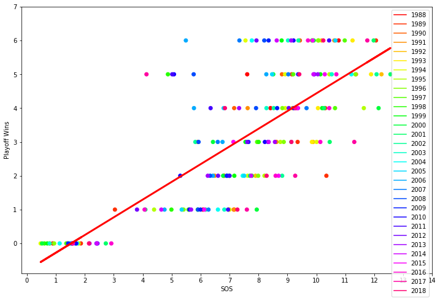

```
                            OLS Regression Results
==============================================================================
Dep. Variable:                 t_wins   R-squared:                       0.607
Model:                            OLS   Adj. R-squared:                  0.605
Method:                 Least Squares   F-statistic:                     331.5
Date:                Fri, 19 Jul 2019   Prob (F-statistic):           1.95e-45
Time:                        19:14:58   Log-Likelihood:                -357.10
No. Observations:                 217   AIC:                             718.2
Df Residuals:                     215   BIC:                             725.0
Df Model:                           1
Covariance Type:            nonrobust
==============================================================================
                 coef    std err          t      P>|t|      [0.025      0.975]
------------------------------------------------------------------------------
Intercept     -0.7973      0.225     -3.537      0.000      -1.242      -0.353
SOS            0.5233      0.029     18.207      0.000       0.467       0.580
==============================================================================
Omnibus:                       13.882   Durbin-Watson:                   0.599
Prob(Omnibus):                  0.001   Jarque-Bera (JB):               14.841
Skew:                           0.633   Prob(JB):                     0.000599
Kurtosis:                       3.199   Cond. No.                         21.0
==============================================================================

Warnings:
[1] Standard Errors assume that the covariance matrix of the errors is correctly specified.
```

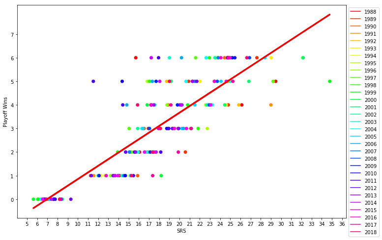

```
                            OLS Regression Results
==============================================================================
Dep. Variable:                 t_wins   R-squared:                       0.718
Model:                            OLS   Adj. R-squared:                  0.716
Method:                 Least Squares   F-statistic:                     546.2
Date:                Fri, 19 Jul 2019   Prob (F-statistic):           6.09e-61
Time:                        19:14:59   Log-Likelihood:                -321.15
No. Observations:                 217   AIC:                             646.3
Df Residuals:                     215   BIC:                             653.1
Df Model:                           1
Covariance Type:            nonrobust
==============================================================================
                 coef    std err          t      P>|t|      [0.025      0.975]
------------------------------------------------------------------------------
Intercept     -1.9636      0.224     -8.750      0.000      -2.406      -1.521
SRS            0.2816      0.012     23.370      0.000       0.258       0.305
==============================================================================
Omnibus:                       24.788   Durbin-Watson:                   1.160
Prob(Omnibus):                  0.000   Jarque-Bera (JB):               30.634
Skew:                           0.793   Prob(JB):                     2.23e-07
Kurtosis:                       3.933   Cond. No.                         57.8
==============================================================================

Warnings:
[1] Standard Errors assume that the covariance matrix of the errors is correctly specified.
```

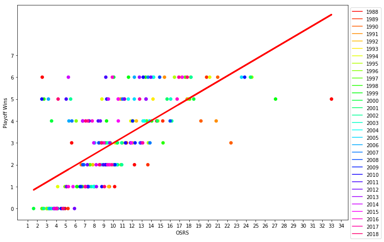

```
                            OLS Regression Results
==============================================================================
Dep. Variable:                 t_wins   R-squared:                       0.439
Model:                            OLS   Adj. R-squared:                  0.436
Method:                 Least Squares   F-statistic:                     168.2
Date:                Fri, 19 Jul 2019   Prob (F-statistic):           8.42e-29
Time:                        19:14:59   Log-Likelihood:                -395.61
No. Observations:                 217   AIC:                             795.2
Df Residuals:                     215   BIC:                             802.0
Df Model:                           1
Covariance Type:            nonrobust
==============================================================================
                 coef    std err          t      P>|t|      [0.025      0.975]
------------------------------------------------------------------------------
Intercept      0.4364      0.222      1.961      0.051      -0.002       0.875
OSRS           0.2553      0.020     12.971      0.000       0.216       0.294
==============================================================================
Omnibus:                       18.007   Durbin-Watson:                   0.801
Prob(Omnibus):                  0.000   Jarque-Bera (JB):               20.369
Skew:                           0.747   Prob(JB):                     3.78e-05
Kurtosis:                       3.154   Cond. No.                         24.8
==============================================================================

Warnings:
[1] Standard Errors assume that the covariance matrix of the errors is correctly specified.
```

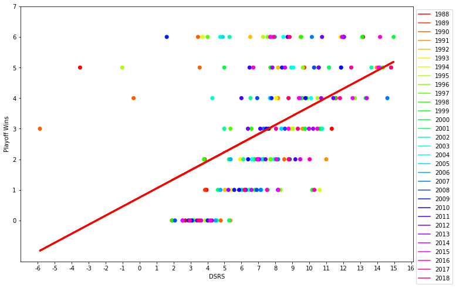

```
                            OLS Regression Results
==============================================================================
Dep. Variable:                 t_wins   R-squared:                       0.245
Model:                            OLS   Adj. R-squared:                  0.242
Method:                 Least Squares   F-statistic:                     69.93
Date:                Fri, 19 Jul 2019   Prob (F-statistic):           7.71e-15
Time:                        19:15:00   Log-Likelihood:                -427.77
No. Observations:                 217   AIC:                             859.5
Df Residuals:                     215   BIC:                             866.3
Df Model:                           1
Covariance Type:            nonrobust
==============================================================================
                 coef    std err          t      P>|t|      [0.025      0.975]
------------------------------------------------------------------------------
Intercept      0.7531      0.294      2.565      0.011       0.174       1.332
DSRS           0.2962      0.035      8.362      0.000       0.226       0.366
==============================================================================
Omnibus:                       19.443   Durbin-Watson:                   0.451
Prob(Omnibus):                  0.000   Jarque-Bera (JB):               22.875
Skew:                           0.794   Prob(JB):                     1.08e-05
Kurtosis:                       2.925   Cond. No.                         20.8
==============================================================================

Warnings:
[1] Standard Errors assume that the covariance matrix of the errors is correctly specified.
```

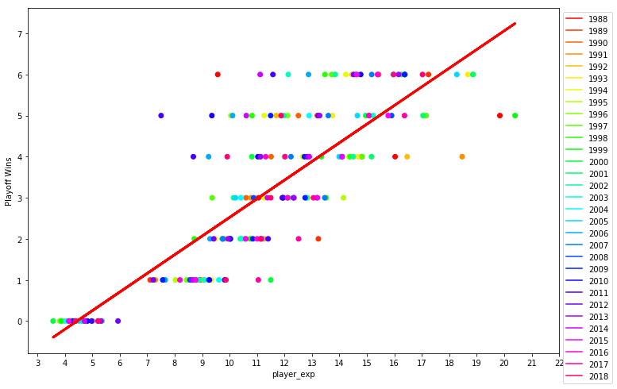

```
                            OLS Regression Results
==============================================================================
Dep. Variable:                 t_wins   R-squared:                       0.707
Model:                            OLS   Adj. R-squared:                  0.705
Method:                 Least Squares   F-statistic:                     518.3
Date:                Fri, 19 Jul 2019   Prob (F-statistic):           3.39e-59
Time:                        19:15:00   Log-Likelihood:                -325.21
No. Observations:                 217   AIC:                             654.4
Df Residuals:                     215   BIC:                             661.2
Df Model:                           1
Covariance Type:            nonrobust
==============================================================================
                 coef    std err          t      P>|t|      [0.025      0.975]
------------------------------------------------------------------------------
Intercept     -2.0194      0.233     -8.685      0.000      -2.478      -1.561
player_exp     0.4542      0.020     22.766      0.000       0.415       0.493
==============================================================================
Omnibus:                       23.851   Durbin-Watson:                   1.091
Prob(Omnibus):                  0.000   Jarque-Bera (JB):               28.319
Skew:                           0.813   Prob(JB):                     7.09e-07
Kurtosis:                       3.699   Cond. No.                         36.9
==============================================================================

Warnings:
[1] Standard Errors assume that the covariance matrix of the errors is correctly specified.
```

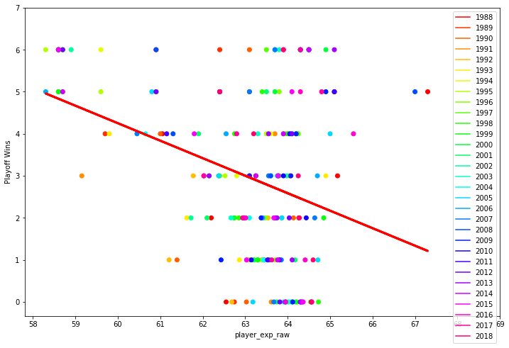

```
                            OLS Regression Results
==============================================================================
Dep. Variable:                 t_wins   R-squared:                       0.128
Model:                            OLS   Adj. R-squared:                  0.124
Method:                 Least Squares   F-statistic:                     31.57
Date:                Fri, 19 Jul 2019   Prob (F-statistic):           5.92e-08
Time:                        19:15:01   Log-Likelihood:                -443.46
No. Observations:                 217   AIC:                             890.9
Df Residuals:                     215   BIC:                             897.7
Df Model:                           1
Covariance Type:            nonrobust
==================================================================================
                     coef    std err          t      P>|t|      [0.025      0.975]
----------------------------------------------------------------------------------
Intercept         29.2218      4.669      6.259      0.000      20.020      38.424
player_exp_raw    -0.4162      0.074     -5.619      0.000      -0.562      -0.270
==============================================================================
Omnibus:                       22.838   Durbin-Watson:                   0.251
Prob(Omnibus):                  0.000   Jarque-Bera (JB):                9.193
Skew:                           0.260   Prob(JB):                       0.0101
Kurtosis:                       2.136   Cond. No.                     2.31e+03
==============================================================================

Warnings:
[1] Standard Errors assume that the covariance matrix of the errors is correctly specified.
[2] The condition number is large, 2.31e+03. This might indicate that there are
strong multicollinearity or other numerical problems.
```

```python
# First we create our dataframe and fill out the years and tourney wins. We then generate the color values for the
# legend and create our dictionary to store expected values, slope and other important information for each year.
# We loop through each column and perform linear regression with that column alone. From there we calculate the
# expected values using the slope and coefficient and then graph the line and values using matplotlib. We create
# the legend and format the colors, size, and labels of the graph.
# We also add the value to the dictionary for later analysis.

colormap = {}

# This function is used to store expected value, slope and the data name
# This is useful for residual analysis so that expected values do not need to be re-calculated
def update_p_reg(p_reg, name, slope, intercept, ev):
    p_reg[name] = {}
    p_reg[name]['slope'] = slope
    p_reg[name]['intercept'] = intercept
    p_reg[name]['ev'] = ev


# This function is used to create the legend. This creates an element that links year to the color used for that year
# on the scatterplot. From there it is added to the legend to increase clarity.
def line(label):
    colormap[label[0]] = label[1]
    return Line2D([0], [0],  color=label[1], label=str(label[0]))

def pickcolor(year):
    return colormap[year]


results_dict = {}

leg = [line(label) for label in zip(year_range, plt.cm.hsv(range(0, 255, int(255/len(year_range)))))]
p_reg = {}

for i in cols:

    result = smf.ols(formula='t_wins ~ {}'.format(i), data=df_means).fit()

    m = result.params[i]
    b = result.params['Intercept']

    xt = range(floor(df_means[i].min()), ceil(df_means[i].max() + 2))
    x = df_means[i].tolist()
    y = [m * a + b for a in x[1:-1]]

    fig, ax = plt.subplots()
    fig.set_size_inches(12, 8)
    ax.plot(x[1:-1], y, color='red', linewidth=3.0)
    ax.scatter(df_means[i], df_means['t_wins'], c = list(map(pickcolor, df_means['year'])))
    ax.legend(handles=leg, bbox_to_anchor=(1, 1))

    plt.xlabel(i)
    plt.ylabel('Playoff Wins')
    plt.xticks(xt, xt)
    plt.yticks(range(8), range(8))

    plt.show()

    print(result.summary())
    update_p_reg(p_reg, i, m, b, y)

    results_dict[i] = result
```

# Model Evaluation

Here we evaluate our linear regression model generated in the previous section.

We test it on data from 2019. Evaluating our models on new data is a very simple process. We reuse our methods for generating data from 1988-2018 to generate a dataframe with only 2019 data. We'll need to weight the player experience we saved in the CSV file with the each team's SRS for that year, since that step is not performed in the CSV generation step.

Back to Table of Contents

```python
latest_year = pd.merge(generate_df(2019), generate_exp_df(2019), how='left', on=['School','year'])

# Calculate better player experience
for index, row in latest_year.iterrows():
    latest_year.loc[index, "player_exp"] = (row['player_exp'] * (row['SRS']))/100

latest_data = latest_year[['SRS', 'SOS', 'OSRS', 'DSRS', 'player_exp', 'player_exp_raw']]
```

Then for each feature we will use its corresponding model to predict the tournament wins for 2019 and compare the correlations.

```python
# Our model won't output whole numbers, so we round each one of them down. Sometimes our model
# will output negative numbers, we simply convert those to 0s.
def round_results(d):
    for k, v in d.iteritems():
        d[k] = round(v-1)
        if d[k] < 0: d[k] = 0


print("\n")

#For each feature, make a prediction for 2019, and print the correlation.
for i in cols:

    predicted = results_dict[i].predict(latest_data)
    round_results(predicted)
    latest_year['predicted'] = predicted

    predicted_res = latest_year.sort_values(by=['predicted'], ascending=False)

    print("Correlation for " + i + ": " + str(predicted_res['t_wins'].corr(predicted_res['predicted'])))
```

```
Correlation for SOS: 0.5296339265170005
Correlation for SRS: 0.7745949929534893
Correlation for OSRS: 0.5102406173302974
Correlation for DSRS: 0.536098761896051
Correlation for player_exp: 0.7937202704793145
Correlation for player_exp_raw: 0.14087604129981232
```

The results are rather disappointing. SRS seems to be the dominating factor and is slightly aided when collinearity with player experience (the purpose of the player_exp variable). Raw player experience does not seems to yield a meaningful correlation. Even accounting for the obivous influence of outliers shown in the summary, the correlation would be pretty slight. But the fact that including player experience boosts the accuracy of SRS is strange. The player_exp_raw metric has a negative relationship with wins. Shouldn't more experience mean more success? Maybe during calculation of player_exp, when player_exp_raw is multiplied by SRS and .01, the influence of outliers is reduced enough that a slightly positive relationship between experience and wins makes the contribution of .02 to the correlation...

We'll test a few more models. Since it looks like there could be a slightly exponential relationship between SRS/player_exp and wins, models that include 2nd degrees parameters are included. Some models will also test the direct influence of SOS and interactions between SOS and player_exp.

We will also train models on the dataframe that contains raw data for every year and every team. This dataframe is not the one containing the means for each winning category (ie when we averaged all data per #wins). This goes against our caveat about categorical data and linear regression. But maybe by including exponential terms for player_exp and SRS, we can offset the effect of skew due to a larger number of lower win teams.

**Note:** The scatterplots below use plotly.express which is notorious for installation issues on MAC-OS. Pass in 1 for the last argument of correlationAndChart to plot predictions next to real wins.

```python
# This is a helper function for plotting and observing correlations of different models.
# If switch is 1, the predictions will be plotted.
def correlationAndChart(result, data, equation, switch):

    predicted = result.predict(latest_data)
    round_results(predicted)
    latest_year['predicted'] = predicted

    predicted_res = latest_year.sort_values(by=['predicted'], ascending=False)

    if switch == 1:

        schools = list(predicted_res['School'].head(20))
        n_schools = len(schools)

        pred = list(predicted_res['predicted'].head(20))
        act = list(predicted_res['t_wins'].head(20))

        gf = pd.DataFrame(dict(school=schools*2, wins=pred + act, how=["Predicted Wins"]*n_schools + ["Actual Wins"]*n_schools))

        fig = px.scatter(gf, x="wins", y="school", color="how")

        fig.show()

    print("\nCorrelation for " + equation + ": " + str(predicted_res['t_wins'].corr(predicted_res['predicted'])) + "\n")



equa = 't_wins ~ np.power(player_exp, 2)'
result = smf.ols(formula=equa, data=df_means).fit()

correlationAndChart(result, latest_data, equa, 0)


equa = 't_wins ~ SOS + player_exp_raw'
result = smf.ols(formula=equa, data=df_means).fit()

correlationAndChart(result, latest_data, equa, 0)



equa = 't_wins ~ player_exp + np.power(SRS, 2) + player_exp*SOS'
result = smf.ols(formula=equa, data=df_means).fit()

correlationAndChart(result, latest_data, equa, 0)



equa = 't_wins ~ SRS'
result = smf.ols(formula=equa, data=df_means).fit()

correlationAndChart(result, latest_data, equa, 0)

print("\n\n===================================================================================")
print("The models below trained on ALL data, not just the means per Year per #Wins")
print("===================================================================================\n\n")


#HERE WE USED joined_df, NOT df_means!!
equa = 't_wins ~ SRS'
result = smf.ols(formula=equa, data=joined_df).fit()

correlationAndChart(result, latest_data, equa, 0)


equa = 't_wins ~ np.power(SRS,2)'
result = smf.ols(formula=equa, data=joined_df).fit()

correlationAndChart(result, latest_data, equa, 0)


equa = 't_wins ~ np.power(player_exp_raw,2) + SOS + SRS + player_exp + np.power(player_exp,2) + player_exp_raw*np.power(SRS, 2)*SOS'
result = smf.ols(formula=equa, data=joined_df).fit()

print(result.summary())

correlationAndChart(result, latest_data, equa, 0)
```

```
Correlation for t_wins ~ np.power(player_exp, 2): 0.7868556840399172


Correlation for t_wins ~ SOS + player_exp_raw: 0.4665522456848549


Correlation for t_wins ~ player_exp + np.power(SRS, 2) + player_exp*SOS: 0.7608235041252525


Correlation for t_wins ~ SRS: 0.7745949929534893



===================================================================================
The models below trained on ALL data, not just the means per Year per #Wins
===================================================================================



Correlation for t_wins ~ SRS: 0.6729638766655928


Correlation for t_wins ~ np.power(SRS,2): 0.7445158955966474

                            OLS Regression Results
==============================================================================
Dep. Variable:                 t_wins   R-squared:                       0.470
Model:                            OLS   Adj. R-squared:                  0.467
Method:                 Least Squares   F-statistic:                     158.3
Date:                Fri, 19 Jul 2019   Prob (F-statistic):          3.77e-261
Time:                        20:30:08   Log-Likelihood:                -2754.4
No. Observations:                1974   AIC:                             5533.
Df Residuals:                    1962   BIC:                             5600.
Df Model:                          11
Covariance Type:            nonrobust
=======================================================================================================
                                          coef    std err          t      P>|t|      [0.025      0.975]
-------------------------------------------------------------------------------------------------------
Intercept                              -0.1848      3.313     -0.056      0.956      -6.683       6.313
np.power(player_exp_raw, 2)            -0.0003      0.001     -0.300      0.764      -0.002       0.002
```

[output cut: 8 more lines]

```
np.power(SRS, 2):SOS                    0.0012      0.001      1.381      0.168      -0.001       0.003
player_exp_raw:np.power(SRS, 2):SOS -1.507e-05   1.41e-05     -1.067      0.286   -4.28e-05    1.26e-05
==============================================================================
Omnibus:                      322.705   Durbin-Watson:                   2.026
Prob(Omnibus):                  0.000   Jarque-Bera (JB):              722.577
Skew:                           0.933   Prob(JB):                    1.24e-157
Kurtosis:                       5.303   Cond. No.                     2.17e+07
==============================================================================

Warnings:
[1] Standard Errors assume that the covariance matrix of the errors is correctly specified.
[2] The condition number is large, 2.17e+07. This might indicate that there are
strong multicollinearity or other numerical problems.

Correlation for t_wins ~ np.power(player_exp_raw,2) + SOS + SRS + player_exp + np.power(player_exp,2) + player_exp_raw*np.power(SRS, 2)*SOS: 0.8264888422926633
```

The last model takes into account various interactions between different parameters and is also trained on all data. It both uses more data and features a more robust interaction system, but performs only marginally better then our non-polynomial linear regression model. The interaction terms are not particularly meaningful as shown by their low coefficients.

# Conclusion

In conclusion, we saw that raw player experience does not make a strong playoff team. SRS proved to be the dominant metric and in hindsight this seems quite obvious. The best regular season teams usually win. Our data shows that they recieve a marginal boost with more experienced players, but our results are truthfully pretty negligible in that regard. The player_experience_raw feature is not multiplied by SRS and musters a meager correlation of .14. This shows that player experience is simply not that important in and of itself.

Further experiments should account for outliers in all fields. This is very apparent when looking at the regression results for player_exp_raw and DSRS. Sometimes strange things happen to teams or sudden injuries threw the group dynamic off balance. Again, we have not accounted for numerous factors that could affect a college basketball team's performance.

Our definition of player experience could use some work. Our system of weighting by class and multiplying by SRS accounts for experience and team skill but there may be problems within our definition of experience. Maybe our weights should be completely different, although after trying many different configurations, I doubt it's the weights themsleves that cause the problem. More likely we should account for each player's playing time and previous tournament experience. We could also consider the exact effect of accruing more experience. Maybe players who have played in one NCAA Tournament will play much better than those who have not, but a player with 3 tournaments will not play significantly differently than one with 2 (on average of course).

Hopefully you've learned a lot by now, especially regarding scraping and exploratory data analysis with statsmodels. Though we were not able to prove anything particularly shocking, the folks over at 538 sometimes do. If you want to explore different approaches to sport statistics, we found a few interesting articles.

https://fivethirtyeight.com/features/when-we-say-70-percent-it-really-means-70-percent/ - Interpreting sports probabilities with better context

https://fivethirtyeight.com/methodology/how-our-march-madness-predictions-work-2/ - The weeds of bracket prediction algorithms

In addition, some statisticians and sports analysts have conducted very similar experiments with more advanced methodology. The paper linked below set out with the same goals we had. The authors also found a negligible relationship between player experience and playoff success.

https://content.iospress.com/articles/journal-of-sports-analytics/jsa180331

Back to Table of Contents